# Session 6: Inferential network models

Exponential random graph models (ERGMs)

Published

October 4, 2026

## Goals

- understand why ties cannot be modelled as independent observations,
- read an ERGM as a model of *which local configurations* make a network likely,
- fit, interpret and check ERGMs in R.

**Important**

ERGMs live in the **statnet** family of packages, which use their own `network` objects and clash with `igraph` function names. Start this session in a fresh R session (Session → Restart R) and do **not** load igraph. To convert between the two formats, use `intergraph::asNetwork()` and `intergraph::asIgraph()`.

```r
library(ergm)
data(florentine)   # loads flomarriage and flobusiness
flomarriage
```

```
 Network attributes:
  vertices = 16
  directed = FALSE
  hyper = FALSE
  loops = FALSE
  multiple = FALSE
  bipartite = FALSE
  total edges= 20
    missing edges= 0
    non-missing edges= 20

 Vertex attribute names:
    priorates totalties vertex.names wealth

No edge attributes
```

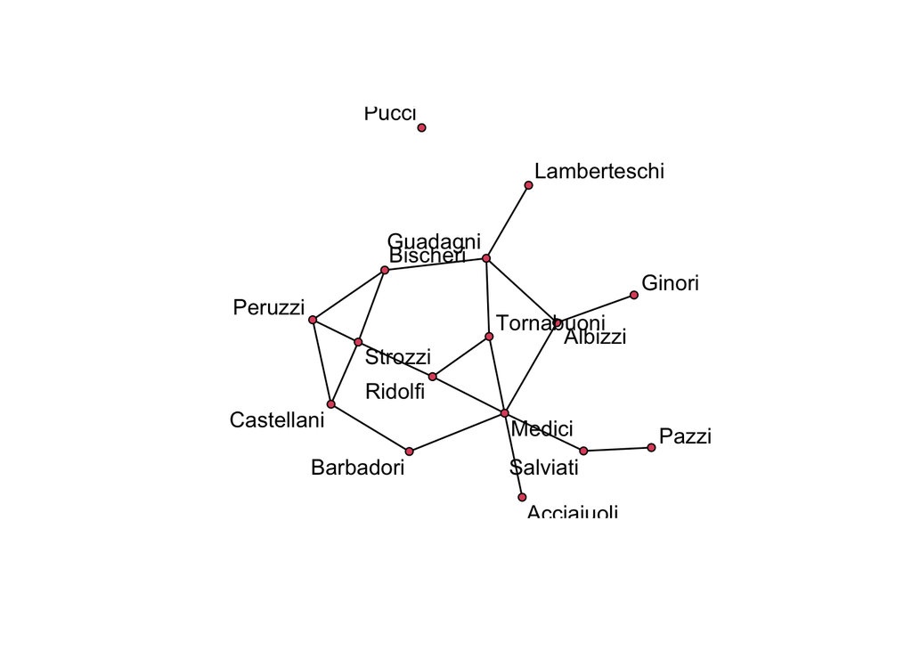

```r
plot(flomarriage, displaylabels = TRUE)
```

Marriage ties among Renaissance Florentine families: a classic network of alliance politics.

## 1. From the random graph to a logit

The simplest ERGM contains only an `edges` term. It is the random graph from Session 5, written as a statistical model.

```r
m1 <- ergm(flomarriage ~ edges)
summary(m1)
```

```
Call:
ergm(formula = flomarriage ~ edges)

Maximum Likelihood Results:

      Estimate Std. Error MCMC % z value Pr(>|z|)
edges  -1.6094     0.2449      0  -6.571   <1e-04 ***
---
Signif. codes:  0 '***' 0.001 '**' 0.01 '*' 0.05 '.' 0.1 ' ' 1

     Null Deviance: 166.4  on 120  degrees of freedom
 Residual Deviance: 108.1  on 119  degrees of freedom

AIC: 110.1  BIC: 112.9  (Smaller is better. MC Std. Err. = 0)
```

**NoteThink first**

Convert the `edges` coefficient into a probability with `plogis()`. Compare it to the network density. Why are they the same?

```r
plogis(coef(m1))
```

```
    edges
0.1666667
```

```r
network.density(flomarriage)
```

```
[1] 0.1666667
```

## 2. Adding node attributes

Do wealthier families have more marriage ties?

```r
m2 <- ergm(flomarriage ~ edges + nodecov("wealth"))
summary(m2)
```

```
Call:
ergm(formula = flomarriage ~ edges + nodecov("wealth"))

Maximum Likelihood Results:

                Estimate Std. Error MCMC % z value Pr(>|z|)
edges          -2.594929   0.536056      0  -4.841   <1e-04 ***
nodecov.wealth  0.010546   0.004674      0   2.256   0.0241 *
---
Signif. codes:  0 '***' 0.001 '**' 0.01 '*' 0.05 '.' 0.1 ' ' 1

     Null Deviance: 166.4  on 120  degrees of freedom
 Residual Deviance: 103.1  on 118  degrees of freedom

AIC: 107.1  BIC: 112.7  (Smaller is better. MC Std. Err. = 0)
```

So far, ties are still treated as independent given the attributes. This model is a logistic regression on all pairs of families.

## 3. Adding dependence: triangles

Now the key step: does a tie become more likely if two families already share a partner? The `gwesp` term captures this tendency towards triangle closure.

```r
m3 <- ergm(
  flomarriage ~ edges + nodecov("wealth") + gwesp(decay = 0.25, fixed = TRUE),
  control = control.ergm(seed = 2027)
)
summary(m3)
```

```
Call:
ergm(formula = flomarriage ~ edges + nodecov("wealth") + gwesp(decay = 0.25,
    fixed = TRUE), control = control.ergm(seed = 2027))

Monte Carlo Maximum Likelihood Results:

                  Estimate Std. Error MCMC % z value Pr(>|z|)
edges            -2.594611   0.526639      0  -4.927   <1e-04 ***
nodecov.wealth    0.010365   0.004656      0   2.226    0.026 *
gwesp.fixed.0.25  0.001345   0.274566      0   0.005    0.996
---
Signif. codes:  0 '***' 0.001 '**' 0.01 '*' 0.05 '.' 0.1 ' ' 1

     Null Deviance: 166.4  on 120  degrees of freedom
 Residual Deviance: 103.1  on 117  degrees of freedom

AIC: 109.1  BIC: 117.5  (Smaller is better. MC Std. Err. = 0.004453)
```

**WarningDiscuss**

Ties now depend on other ties. That is why ERGMs are estimated by simulation (MCMC) rather than by plain maximum likelihood. Connect this to the dependence problem from Session 1.

## 4. Does the model reproduce the network?

Goodness of fit: simulate networks from the fitted model and compare their statistics with the observed network.

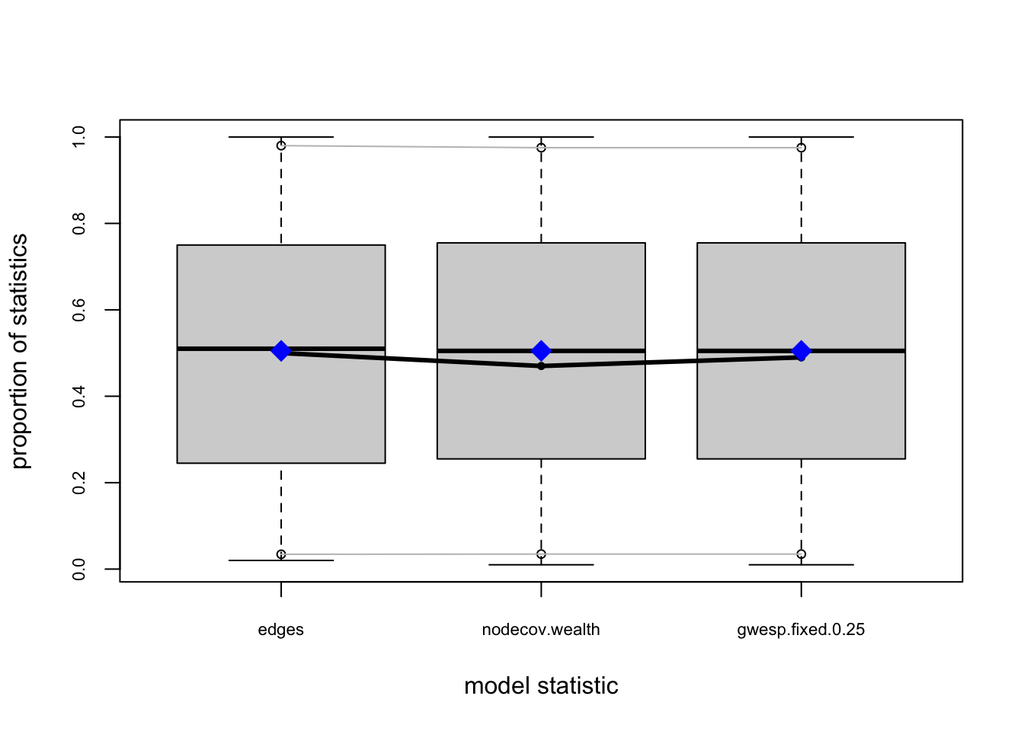

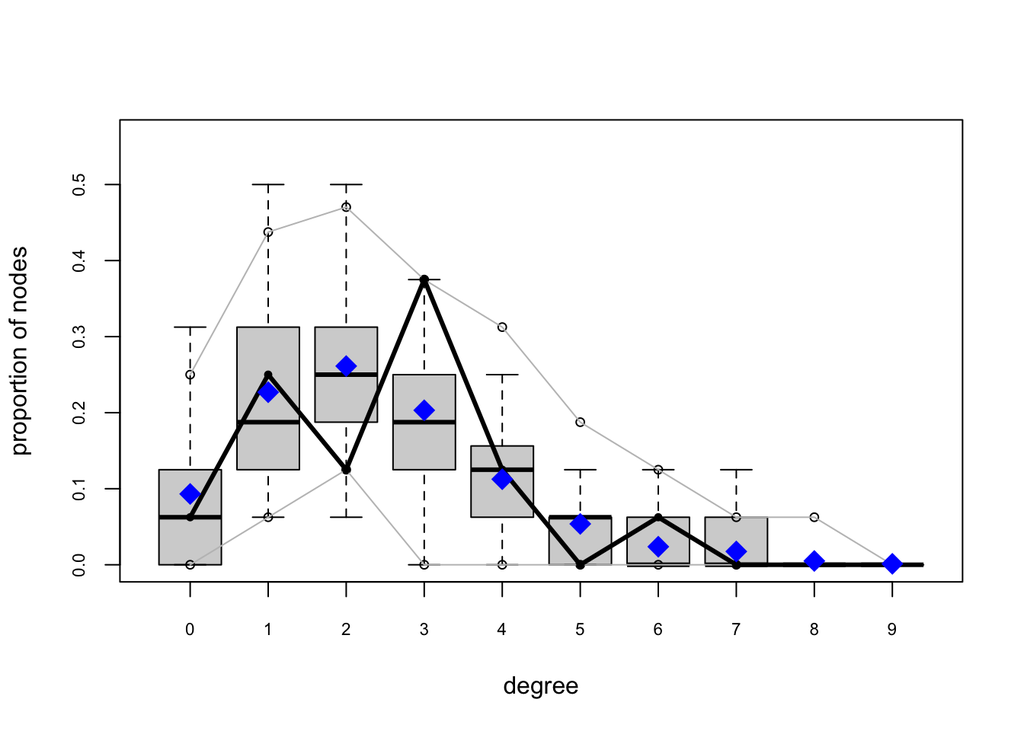

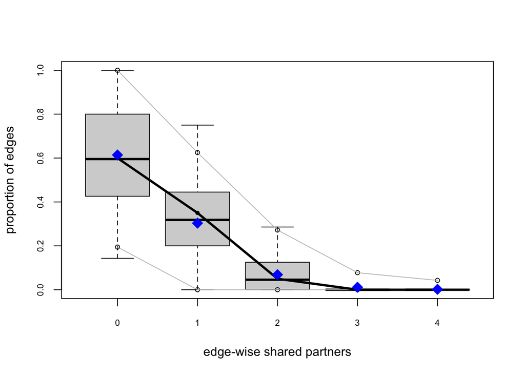

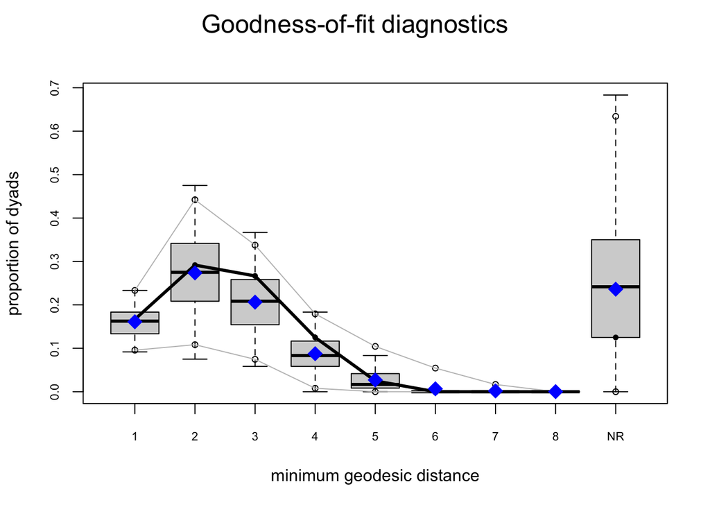

```r
fit <- gof(m3)
plot(fit)
```

If the observed values (black line) lie within the simulated range (boxplots), the model captures that feature.

## Your turn

**TipExercise**

1. Fit the same three models to `flobusiness` (business ties). Do the conclusions change?
2. Add `nodematch()` for a categorical attribute in your own data to test homophily.
3. In two sentences each, interpret the `wealth` and `gwesp` coefficients of your final model for a political science audience.

```r
# your code here
```